# PCA_Analysis

### PCA Analysis

1. Load necessary libraries
2. Import the imputed data file created from imputation_workflow
3. Make sure col and row names are set properly, and remove if necessary

```r
library(tidyr)
library(dplyr)
```

```r
library(ggplot2)
setwd("C:/Users/mdzievit.IASTATE/Dropbox/Classes/EEOB_546X/PEB_Power_Final_Project/Structure_Analysis/")
data <- read.delim("imputed_genetic_map_data_EXPIM2012_wh.txt",header = TRUE)
rownames(data) <- data[,1]
data <- data[,-1]
```

4. Run PCA analysis. Paper did not give a lot of details regardint their methods and settings they used.
- Set 2 new variables x and VAR. These are the PC scores (x) and the variance explained by each of the PCs

```r
pca.data <- prcomp(data,center = TRUE)
x.pca.data <- pca.data$x
x.pca.data <- as.data.frame(x.pca.data)
var.pca.data <- summary(pca.data)
var.pca.data <- var.pca.data$importance
var.pca.data <- var.pca.data[2,]
```

## Import genotype information to make PCA plots

# Plot #1 using all sub-populations

1. Import the genotype information file. Skipping the first line as it is just a descriptor that it is a table. Checked the head information in gitbash
- Also need to rename and add the genotype name column in the x.pca.data so we can join them later

```r
genotype <- read.delim("Table_S1.txt",header = TRUE, skip = 1)
colnames(genotype)
```

```
##  [1] "SolCAP.T.number"           "Donor.number.Variety.Name"
##  [3] "LA.number..if.available."  "PI.number..if.available."
##  [5] "Synonyms"                  "Market.Class"
##  [7] "Scientific.Name"           "Name.of.Donor"
##  [9] "Donor.Source"              "Donor.Institution"
## [11] "Origin.Country"            "Origin.State.Province"
## [13] "Adaptation..Humid.Arid."   "Male"
## [15] "Female"                    "Other.e.g..BC..IBC"
```

```r
genotype <- genotype %>% select(SolCAP.T.number,Market.Class)
x.pca.data$SolCAP.T.number <- rownames(x.pca.data)
```

2. Join the genotype information file with the PC file

```r
info.x.pca.data <- genotype %>%
  right_join(x.pca.data, by = c("SolCAP.T.number")) %>%
  droplevels()
```

3. Plot the data to look like the figure from the paper

```r
##Determines the levels of the market
levels(info.x.pca.data$Market.Class)
```

```
## [1] "Cultivated Cherry"       "Fresh market"
## [3] "Fresh market/Processing" "Latin American Cultivar"
## [5] "Processing"              "Vintage"
## [7] "Vintage/Processing"      "Wild"
## [9] "Wild Cherry"
```

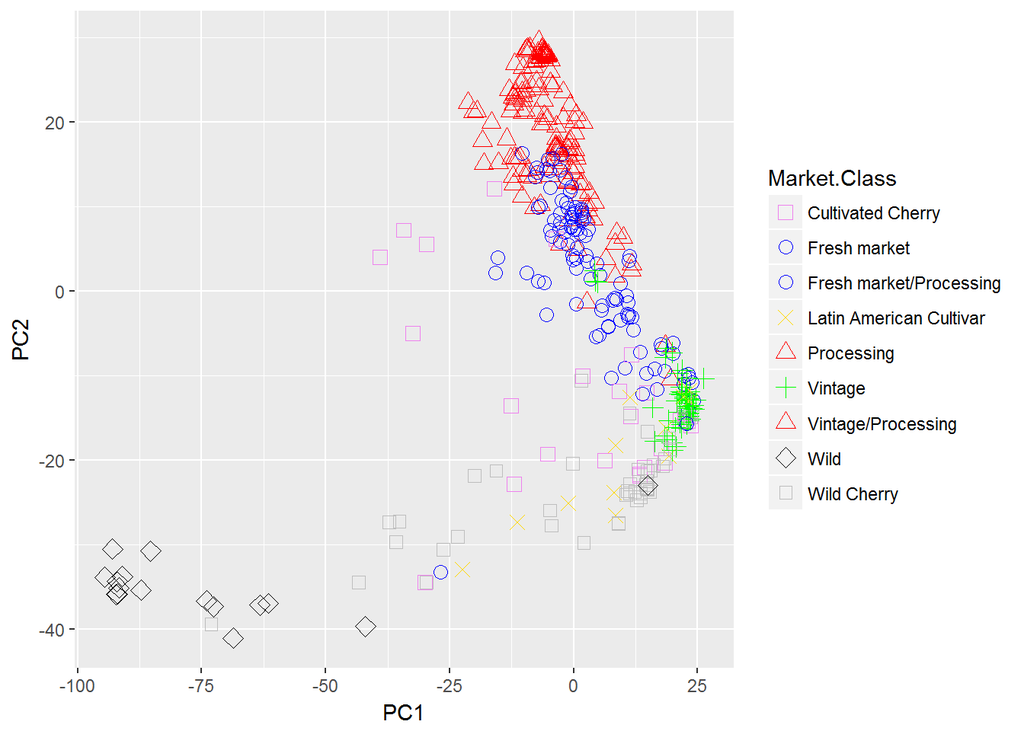

```r
##Identified incorrect classifications in the genotype file related to the original PCA figure. Need to correct these to make the right plot. Fresh market/Processing is one that was changed after so it will be color coded as fresh market. Vintage/processing were ones that were changed after analysis, so will be color coded as processing

##Colors and shapes match the paper
colors <- c("violet","Blue","Blue","Gold","Red","Green","Red","Black","Gray")
shapes <- c(0,1,1,4,2,3,2,5,22)

ggplot(aes(x = PC1, y = PC2),data = info.x.pca.data) +
  geom_point(aes(colour = Market.Class, shape = Market.Class),size = 3) +
  scale_color_manual(values = colors) +
  scale_shape_manual(values = shapes)
```

# Plot#2 Using data for only 3 large-fruited cultivated sub-populations

- This consists of processing, fresh market, and vintage
1. Need to subset the data for the different types for the analysis

```r
data.info <- data
data.info$SolCAP.T.number <- rownames(data.info)
data.info <- genotype %>%
  right_join(data.info, by = c("SolCAP.T.number")) %>%
  droplevels()
data.filt <- data.info %>%
  filter(Market.Class == "Fresh market" | Market.Class == "Processing" |
           Market.Class == "Fresh market/Processing" |
           Market.Class == "Processing" | Market.Class == "Vintage" |
           Market.Class == "Vintage/Processing") %>%
  select(-Market.Class) %>%
  droplevels()
rownames(data.filt) <- data.filt$SolCAP.T.number
data.filt$SolCAP.T.number <- NULL
```

2. Run PCA on the new dataset and subset important information

```r
pca2.data.filt <- prcomp(data.filt,center = TRUE)
x.pca2.data.filt <- pca2.data.filt$x
x.pca2.data.filt <- as.data.frame(x.pca2.data.filt)
var.pca2.data.filt <- summary(pca2.data.filt)
var.pca2.data.filt <- var.pca2.data.filt$importance
var.pca2.data.filt <- var.pca2.data.filt[2,]
```

3. Recombine with the genotype information

```r
x.pca2.data.filt$SolCAP.T.number <- rownames(x.pca2.data.filt)
info.x.pca2.data.filt <- genotype %>%
  right_join(x.pca2.data.filt, by = c("SolCAP.T.number")) %>%
  droplevels()
```

4. Plot the figure using the details from the paper

```r
levels(info.x.pca2.data.filt$Market.Class)
```

```
## [1] "Fresh market"            "Fresh market/Processing"
## [3] "Processing"              "Vintage"
## [5] "Vintage/Processing"
```

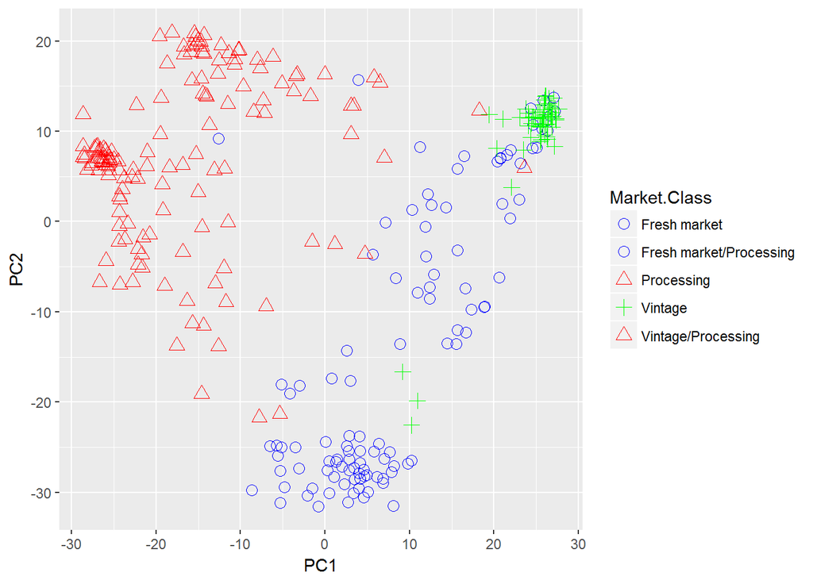

```r
colors2 <- c("Blue","Blue","Red","Green","Red")
shapes2 <- c(1,1,2,3,2)
ggplot(aes(x = PC1, y = PC2),data = info.x.pca2.data.filt) +
  geom_point(aes(colour = Market.Class, shape = Market.Class),size = 3) +
  scale_color_manual(values = colors2) +
  scale_shape_manual(values = shapes2)
```